# Add Some Taste - Salt Injection

Yu-Fen Huang, Yin-Phan Tsang (Advisor)

02 June, 2018

# Introduction

We used two methods to measure the stream discharge: the cross-section area with a current-meter (SonTek FlowTracker Handheld-ADV® (Acoustic Doppler Velocimeter) and the salt injection (Moore, 2003, 2005). Measuring cross-section with current-meter is convenient and widely used in the field (Young. 1950). Yet, the measurement at low flow or turbulent condition could lead to potential errors, despite the Acoustic Doppler probe has minimum depth at 0.02 m in the specification. On the other hand, salt injection requires preparation yet is accurate and not limited by the size of the streams (Moore, 2003). We therefore has flow measured with both methods to validate and ensure the accuracy in flow measurement for building the rating curve.

# Salt Injection

The salt injection can be used for the flow greater than $10 m^3 s^{-1}$, and additionally it works well in steep highly turbulent streams (Moore 2005). The concentration of the salt in stream water can be calculated by the electrical conductivity.

The discharge ($m^3 s^{-1}$) of tracer solution $q(t)=Q×RC(t)$ where Q ($m^3 s^{-1}$) is the stream discharge; $RC(t)$ is the relative concentration of tracer solution ($L/L$) at the flow time ($t$).

# Relationship between Salt Injection and Flow Meter

### Measurement at Lyon Arboretum

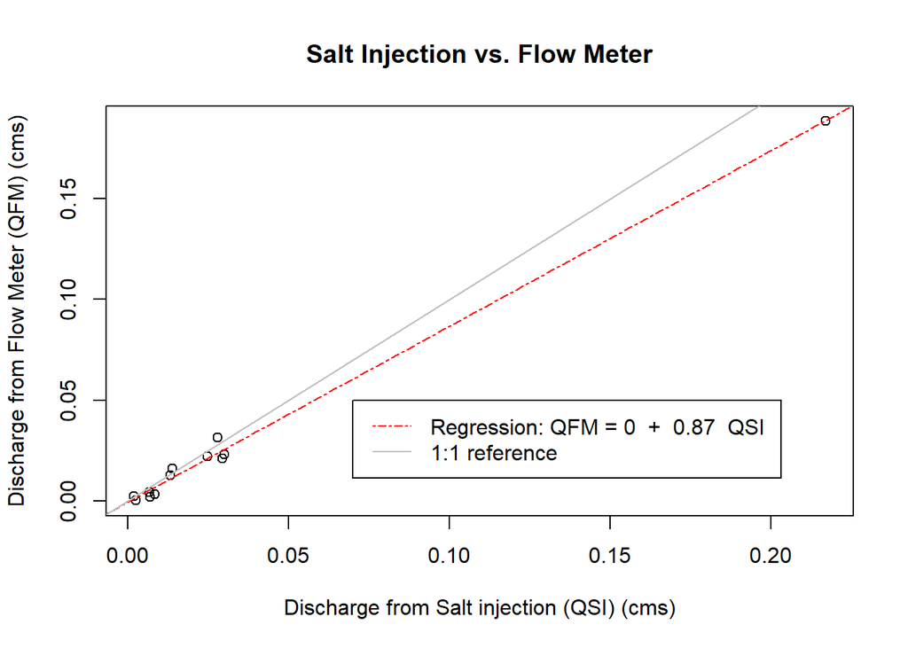

# Reference

- Young, K. B. (1950). A comparative study of mean-section and mid-section methods for computation of discharge measurements (Vol. 1950).
- Moore, R. D. D. (2003). Introduction to Salt Dilution Gauging for Streamflow Measurement: Part 1, 7(4), 20-23.
- Moore, R. D. D. (2005). Inside this issue : Watersheds : A Discussion, 8(2).